# Building A Recommender System

## by Oswaldo Orona Fall 2020.

## for Practical Statistical Learning

```python
import requests
from requests.compat import urljoin
import json
import pandas as pd
import io
import re
import numpy as np
import warnings
import matplotlib.pyplot as plt
import numpy as np
import os
import scipy
from scipy.sparse.linalg import svds
from scipy import spatial
import sklearn.preprocessing as pp
%matplotlib inline
warnings.filterwarnings('ignore')
from sklearn.metrics.pairwise import cosine_similarity
import time
import sys
import math
```

# Data Loading

First we can load the data from the remote interface but to avoid issues with network files are already save in the folder

Instead of load them from the interface we just load them from files

```python
basedata="../recommenderapp/static/data"
moviesraw=pd.read_csv("moviesraw.dat",sep='::',header=None)
moviesraw.columns=["MovieID","Movie","Genres"]
moviesraw.head()
```

|  | MovieID | Movie | Genres |
| --- | --- | --- | --- |
| 0 | 1 | Toy Story (1995) | Animation\|Children's\|Comedy |
| 1 | 2 | Jumanji (1995) | Adventure\|Children's\|Fantasy |
| 2 | 3 | Grumpier Old Men (1995) | Comedy\|Romance |
| 3 | 4 | Waiting to Exhale (1995) | Comedy\|Drama |
| 4 | 5 | Father of the Bride Part II (1995) | Comedy |

```python
usersraw=pd.read_csv("usersraw.dat",sep='::',header=None)
usersraw.columns=["UserID", "Gender", "Age", "Occupation", "Zip-code"]
usersraw.head()
```

|  | UserID | Gender | Age | Occupation | Zip-code |
| --- | --- | --- | --- | --- | --- |
| 0 | 1 | F | 1 | 10 | 48067 |
| 1 | 2 | M | 56 | 16 | 70072 |
| 2 | 3 | M | 25 | 15 | 55117 |
| 3 | 4 | M | 45 | 7 | 02460 |
| 4 | 5 | M | 25 | 20 | 55455 |

```python
ratingsraw=pd.read_csv("ratingsraw.dat",sep='::',header=None)
ratingsraw.columns=["UserID", "MovieID", "Rating", "Timestamp"]
ratingsraw.head()
```

|  | UserID | MovieID | Rating | Timestamp |
| --- | --- | --- | --- | --- |
| 0 | 1 | 1193 | 5 | 978300760 |
| 1 | 1 | 661 | 3 | 978302109 |
| 2 | 1 | 914 | 3 | 978301968 |
| 3 | 1 | 3408 | 4 | 978300275 |
| 4 | 1 | 2355 | 5 | 978824291 |

# Data transformation

The first step manipulating the movies data to extract year, title and break down the category data. This step is also used to extract and format the location of the image files.

```python
movies=moviesraw
movies.Movie=movies.Movie.str.replace(r"\(.*\) ?\(","(")
movies[["Text","Year"]]=moviesraw.Movie.str.split(r" \(",expand=True,n=1)
movies.Year=movies.Year.str.replace(")","").astype(int)
movies.Text=movies.Text.str.replace(r"[^a-zA-Z ]","")
movies['Filename']="images/movies/"+movies.MovieID.astype(str)+".jpg"
movies[["Cat1","Cat2","Cat3","Cat4","Cat5","Cat6"]]=movies.Genres.str.split(r"|",expand=True,n=5)
movies.head()
```

|  | MovieID | Movie | Genres | Text | Year | Filename | Cat1 | Cat2 | Cat3 | Cat4 | Cat5 | Cat6 |
| --- | --- | --- | --- | --- | --- | --- | --- | --- | --- | --- | --- | --- |
| 0 | 1 | Toy Story (1995) | Animation\|Children's\|Comedy | Toy Story | 1995 | images/movies/1.jpg | Animation | Children's | Comedy | None | None | None |
| 1 | 2 | Jumanji (1995) | Adventure\|Children's\|Fantasy | Jumanji | 1995 | images/movies/2.jpg | Adventure | Children's | Fantasy | None | None | None |
| 2 | 3 | Grumpier Old Men (1995) | Comedy\|Romance | Grumpier Old Men | 1995 | images/movies/3.jpg | Comedy | Romance | None | None | None | None |
| 3 | 4 | Waiting to Exhale (1995) | Comedy\|Drama | Waiting to Exhale | 1995 | images/movies/4.jpg | Comedy | Drama | None | None | None | None |
| 4 | 5 | Father of the Bride Part II (1995) | Comedy | Father of the Bride Part II | 1995 | images/movies/5.jpg | Comedy | None | None | None | None | None |

I need to correct the title for the movies that have a "The" appended to the end

```python
fixname=movies.Text.str.extractall(r'(?P<base>^[\w ]*)(?P<space>[\s])(?P<the>The$)')
fixname['final']=fixname.the+fixname.space+fixname.base
fixname=fixname.reset_index()
fixname=fixname[['level_0','final']]
fixname=fixname.rename(columns={'level_0': 'MovieID', 'final': 'Title'})
fixname=fixname.set_index("MovieID")
movies=movies.join(fixname)
movies.Title=movies['Title'].fillna(movies['Text'])
movies.head()
```

|  | MovieID | Movie | Genres | Text | Year | Filename | Cat1 | Cat2 | Cat3 | Cat4 | Cat5 | Cat6 | Title |
| --- | --- | --- | --- | --- | --- | --- | --- | --- | --- | --- | --- | --- | --- |
| 0 | 1 | Toy Story (1995) | Animation\|Children's\|Comedy | Toy Story | 1995 | images/movies/1.jpg | Animation | Children's | Comedy | None | None | None | Toy Story |
| 1 | 2 | Jumanji (1995) | Adventure\|Children's\|Fantasy | Jumanji | 1995 | images/movies/2.jpg | Adventure | Children's | Fantasy | None | None | None | Jumanji |
| 2 | 3 | Grumpier Old Men (1995) | Comedy\|Romance | Grumpier Old Men | 1995 | images/movies/3.jpg | Comedy | Romance | None | None | None | None | Grumpier Old Men |
| 3 | 4 | Waiting to Exhale (1995) | Comedy\|Drama | Waiting to Exhale | 1995 | images/movies/4.jpg | Comedy | Drama | None | None | None | None | Waiting to Exhale |
| 4 | 5 | Father of the Bride Part II (1995) | Comedy | Father of the Bride Part II | 1995 | images/movies/5.jpg | Comedy | None | None | None | None | None | Father of the Bride Part II |

This steps creates a unique list of Categories

```python
cat_cols = [col for col in movies.columns if 'Cat' in col]
categories= pd.DataFrame(columns=['MovieID','Category'])
for cat_col in cat_cols:
    catadd=movies.dropna(subset=[cat_col])[["MovieID",cat_col]]
    catadd.columns=["MovieID",'Category']
    categories=categories.append(catadd, ignore_index=True)
ucat=categories.Category.unique()
ucat.sort()
ucategories=pd.DataFrame(data=ucat,columns=['Category'])
ucategories
```

|  | Category |
| --- | --- |
| 0 | Action |
| 1 | Adventure |
| 2 | Animation |
| 3 | Children's |
| 4 | Comedy |
| 5 | Crime |
| 6 | Documentary |
| 7 | Drama |
| 8 | Fantasy |
| 9 | Film-Noir |
| 10 | Horror |
| 11 | Musical |
| 12 | Mystery |
| 13 | Romance |
| 14 | Sci-Fi |
| 15 | Thriller |
| 16 | War |
| 17 | Western |

The movie Matrix is produce

```python
movies=movies.reset_index()
movies=movies[['MovieID','Movie','Title','Year','Filename']]
movies.head()
```

|  | MovieID | Movie | Title | Year | Filename |
| --- | --- | --- | --- | --- | --- |
| 0 | 1 | Toy Story (1995) | Toy Story | 1995 | images/movies/1.jpg |
| 1 | 2 | Jumanji (1995) | Jumanji | 1995 | images/movies/2.jpg |
| 2 | 3 | Grumpier Old Men (1995) | Grumpier Old Men | 1995 | images/movies/3.jpg |
| 3 | 4 | Waiting to Exhale (1995) | Waiting to Exhale | 1995 | images/movies/4.jpg |
| 4 | 5 | Father of the Bride Part II (1995) | Father of the Bride Part II | 1995 | images/movies/5.jpg |

Both data Matrix are save for use by the application.

```python
ucategories.to_feather(os.path.join(basedata,'categories.feather'))
```

```python
movies.to_feather(os.path.join(basedata,'movies.feather'))
```

# Recommendation Based on Genres - Approach 1

## Data Manipulation

Each movie can belong to multiple genres. The first step is to break down the movies into multiple generes. this steps will generate one row for movie per category. At this point we only need to do a simple mean per movie based on ratings. I calculate the average rating per user so that ratings can ne normalized per user with the following formulate.

$$ r_a= \frac{\sum_i{r_m-\frac{\sum_i{r_u}}{n_u}}}{n_m}$$

Where

- $r_a$ is the mean user adjusted rating.
- $r_u$ are ratings per user
- $n_u$ total number of rating per user
- $r_m$ are ratings per movie
- $n_m$ total number of rating per movie

```python
ratings=ratingsraw
usermean=ratings[['UserID','Rating']].groupby('UserID').mean('Rating')
usermean.columns=['MeanUserRating']
usermean.head()
```

| UserID | MeanUserRating |
| --- | --- |
| 1 | 4.188679 |
| 2 | 3.713178 |
| 3 | 3.901961 |
| 4 | 4.190476 |
| 5 | 3.146465 |

The Adjusted Rating is then calculated.

```python
ratings=ratings.set_index('UserID')
ratings=ratings.join(usermean)
ratings['MeanRating']=ratings['Rating']-ratings['MeanUserRating']
ratings.head()
```

| UserID | MovieID | Rating | Timestamp | MeanUserRating | MeanRating |
| --- | --- | --- | --- | --- | --- |
| 1 | 1193 | 5 | 978300760 | 4.188679 | 0.811321 |
| 1 | 661 | 3 | 978302109 | 4.188679 | -1.188679 |
| 1 | 914 | 3 | 978301968 | 4.188679 | -1.188679 |
| 1 | 3408 | 4 | 978300275 | 4.188679 | -0.188679 |
| 1 | 2355 | 5 | 978824291 | 4.188679 | 0.811321 |

The Mean rating is now calculated based on the adjusted Means per user.

```python
ratingmean=ratings[['MovieID','MeanRating']].groupby('MovieID').mean('MeanRating')
ratingmean.head()
```

| MovieID | MeanRating |
| --- | --- |
| 1 | 0.479497 |
| 2 | -0.324143 |
| 3 | -0.440247 |
| 4 | -0.698816 |
| 5 | -0.419777 |

The ratings and the average per category are join into a single table.

```python
categories=categories.set_index('MovieID')
categoriesrating=categories.join(ratingmean)
categoriesrating.head()
```

| MovieID | Category | MeanRating |
| --- | --- | --- |
| 1 | Animation | 0.479497 |
| 1 | Children's | 0.479497 |
| 1 | Comedy | 0.479497 |
| 2 | Adventure | -0.324143 |
| 2 | Children's | -0.324143 |

We can see that there is one outliner with a mean rating of more than 3. This is becuase there is only one rating of that move as we can see below.

```
0.5581255342140179
```

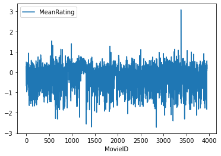

```python
ratingmean=ratingmean.reset_index()
ratingmean.plot(x='MovieID',y=['MeanRating'])
ratingmean=ratingmean.set_index('MovieID')
print(ratingmean.MeanRating.std())
```

```python
categoriesrating.loc[categoriesrating.MeanRating>2.9]
```

| MovieID | Category | MeanRating |
| --- | --- | --- |
| 3382 | Drama | 3.072727 |

Only one rating for "Guess Whos Coming to Dinner"

```python
print(movies.loc[3382].Title)
ratings[ratings.MovieID==3382]
```

```
Guess Whos Coming to Dinner
```

| UserID | MovieID | Rating | Timestamp | MeanUserRating | MeanRating |
| --- | --- | --- | --- | --- | --- |
| 5334 | 3382 | 5 | 960796159 | 1.927273 | 3.072727 |

The above table is pivoted to get a full sparse matrix

```python
catmatrix=categoriesrating.pivot(columns='Category',values='MeanRating')
catmatrix.head()
```

| Category MovieID | Action | Adventure | Animation | Children's | Comedy | Crime | Documentary | Drama | Fantasy | Film-Noir | Horror | Musical | Mystery | Romance | Sci-Fi | Thriller | War | Western |
| --- | --- | --- | --- | --- | --- | --- | --- | --- | --- | --- | --- | --- | --- | --- | --- | --- | --- | --- |
| 1 | NaN | NaN | 0.479497 | 0.479497 | 0.479497 | NaN | NaN | NaN | NaN | NaN | NaN | NaN | NaN | NaN | NaN | NaN | NaN | NaN |
| 2 | NaN | -0.324143 | NaN | -0.324143 | NaN | NaN | NaN | NaN | -0.324143 | NaN | NaN | NaN | NaN | NaN | NaN | NaN | NaN | NaN |
| 3 | NaN | NaN | NaN | NaN | -0.440247 | NaN | NaN | NaN | NaN | NaN | NaN | NaN | NaN | -0.440247 | NaN | NaN | NaN | NaN |
| 4 | NaN | NaN | NaN | NaN | -0.698816 | NaN | NaN | -0.698816 | NaN | NaN | NaN | NaN | NaN | NaN | NaN | NaN | NaN | NaN |
| 5 | NaN | NaN | NaN | NaN | -0.419777 | NaN | NaN | NaN | NaN | NaN | NaN | NaN | NaN | NaN | NaN | NaN | NaN | NaN |

## Selection

In order to get the top n movies per genre at this point it just a selection of the sorted values of the column corresponding to the selected genre.

```python
Category='Sci-Fi'
topn=10
topnmovies=catmatrix[Category].sort_values(ascending=False)[:topn].to_frame()
movies=movies.set_index('MovieID')
topnmovies=topnmovies.join(movies)
topnmovies[['Title','Year',Category]]
```

| MovieID | Title | Year | Sci-Fi |
| --- | --- | --- | --- |
| 260 | Star Wars Episode IV A New Hope | 1977 | 0.745487 |
| 750 | Dr Strangelove or How I Learned to Stop Worryi... | 1963 | 0.741026 |
| 2571 | The Matrix | 1999 | 0.658832 |
| 1196 | Star Wars Episode V The Empire Strikes Back | 1980 | 0.592443 |
| 541 | Blade Runner | 1982 | 0.582136 |
| 1253 | The Day the Earth Stood Still | 1951 | 0.513580 |
| 741 | Ghost in the Shell | 1995 | 0.496135 |
| 1240 | The Terminator | 1984 | 0.473873 |
| 1214 | Alien | 1979 | 0.466961 |
| 1200 | Aliens | 1986 | 0.464889 |

## Save Data

Save the sparse matrix for use in the application

```python
catmatrix=catmatrix.reset_index()
```

```python
catmatrix.to_feather(os.path.join(basedata,'genresmatrix.feather'))
```

# Recommendation Based on Genres - Approach 2

## Data Manipulation

For this method we take the average ratings adjusted per user from the previous approach but this time the process uses the amount of ratings received by each movie to calculate the final rating.

$$ r_a= \frac{\sum_i{r_m-\frac{\sum_i{r_u}}{n_u}}}{n_m}$$

Where

- $r_a$ is the mean user adjusted rating.
- $r_u$ are ratings per user
- $n_u$ total number of rating per user
- $r_m$ are ratings per movie
- $n_m$ total number of rating per movie

$$r_t=r_a(1-\frac{1}{\sqrt(1+{n_r}^2)})$$

Where

- $r_t$ is the thrend adjusted rating.
- $r_a$ is the mean user adjusted rating.
- $n_r$ is the number of rating per movie.

The next step is to calculate the adjusted value based on the above formula.

```python
ratingsnumber=ratings.reset_index()
ratingsnumber=ratingsnumber[['MovieID','UserID']].groupby('MovieID').nunique()
ratingsnumber.columns=["Counts"]
ratingsnumber['AdjustedFactor']=1-1/(1*np.sqrt(1+ratingsnumber.Counts*ratingsnumber.Counts))
ratingsnumber.head()
```

| MovieID | Counts | AdjustedFactor |
| --- | --- | --- |
| 1 | 2077 | 0.999519 |
| 2 | 701 | 0.998573 |
| 3 | 478 | 0.997908 |
| 4 | 170 | 0.994118 |
| 5 | 296 | 0.996622 |

The 2 datasets are join into a single dataset.

```python
categoriesrating=categoriesrating.join(ratingsnumber)
categoriesrating.head()
```

| MovieID | Category | MeanRating | Counts | AdjustedFactor |
| --- | --- | --- | --- | --- |
| 1 | Animation | 0.479497 | 2077.0 | 0.999519 |
| 1 | Children's | 0.479497 | 2077.0 | 0.999519 |
| 1 | Comedy | 0.479497 | 2077.0 | 0.999519 |
| 2 | Adventure | -0.324143 | 701.0 | 0.998573 |
| 2 | Children's | -0.324143 | 701.0 | 0.998573 |

```python
categoriesrating['AdjMeanRating']=categoriesrating.MeanRating*categoriesrating.AdjustedFactor
categoriesrating.head()
```

| MovieID | Category | MeanRating | Counts | AdjustedFactor | AdjMeanRating |
| --- | --- | --- | --- | --- | --- |
| 1 | Animation | 0.479497 | 2077.0 | 0.999519 | 0.479266 |
| 1 | Children's | 0.479497 | 2077.0 | 0.999519 | 0.479266 |
| 1 | Comedy | 0.479497 | 2077.0 | 0.999519 | 0.479266 |
| 2 | Adventure | -0.324143 | 701.0 | 0.998573 | -0.323680 |
| 2 | Children's | -0.324143 | 701.0 | 0.998573 | -0.323680 |

We can then plot like before the results. The plot show that there are no longer movies that have significants spikes due to high single or low number of ratings.

```
0.500696977709134
```

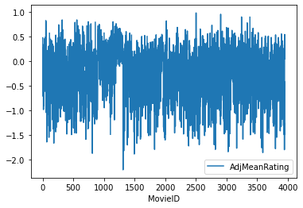

```python
catplot=categoriesrating.reset_index()
catplot=catplot[['MovieID','AdjMeanRating']].groupby('MovieID').mean()
catplot=catplot.reset_index()
catplot.plot(x='MovieID',y=['AdjMeanRating'])
print(catplot.AdjMeanRating.std())
```

```python
catmatrix2=categoriesrating.pivot(columns='Category',values='AdjMeanRating')
catmatrix2.head()
```

| Category MovieID | Action | Adventure | Animation | Children's | Comedy | Crime | Documentary | Drama | Fantasy | Film-Noir | Horror | Musical | Mystery | Romance | Sci-Fi | Thriller | War | Western |
| --- | --- | --- | --- | --- | --- | --- | --- | --- | --- | --- | --- | --- | --- | --- | --- | --- | --- | --- |
| 1 | NaN | NaN | 0.479266 | 0.479266 | 0.479266 | NaN | NaN | NaN | NaN | NaN | NaN | NaN | NaN | NaN | NaN | NaN | NaN | NaN |
| 2 | NaN | -0.32368 | NaN | -0.323680 | NaN | NaN | NaN | NaN | -0.32368 | NaN | NaN | NaN | NaN | NaN | NaN | NaN | NaN | NaN |
| 3 | NaN | NaN | NaN | NaN | -0.439326 | NaN | NaN | NaN | NaN | NaN | NaN | NaN | NaN | -0.439326 | NaN | NaN | NaN | NaN |
| 4 | NaN | NaN | NaN | NaN | -0.694705 | NaN | NaN | -0.694705 | NaN | NaN | NaN | NaN | NaN | NaN | NaN | NaN | NaN | NaN |
| 5 | NaN | NaN | NaN | NaN | -0.418358 | NaN | NaN | NaN | NaN | NaN | NaN | NaN | NaN | NaN | NaN | NaN | NaN | NaN |

## Selection

Doing the same selection as above

```python
Category='Sci-Fi'
topn=10
topnmovies=catmatrix2[Category].sort_values(ascending=False)[:topn].to_frame()
topnmovies=topnmovies.join(movies)
topnmovies[['Title','Year',Category]]
```

| MovieID | Title | Year | Sci-Fi |
| --- | --- | --- | --- |
| 260 | Star Wars Episode IV A New Hope | 1977 | 0.745237 |
| 750 | Dr Strangelove or How I Learned to Stop Worryi... | 1963 | 0.740484 |
| 2571 | The Matrix | 1999 | 0.658578 |
| 1196 | Star Wars Episode V The Empire Strikes Back | 1980 | 0.592245 |
| 541 | Blade Runner | 1982 | 0.581813 |
| 1253 | The Day the Earth Stood Still | 1951 | 0.512661 |
| 741 | Ghost in the Shell | 1995 | 0.494555 |
| 1240 | The Terminator | 1984 | 0.473647 |
| 1214 | Alien | 1979 | 0.466730 |
| 1200 | Aliens | 1986 | 0.464633 |

## Save Data

Save the sparse matrix for use in the application

```python
catmatrix2=catmatrix.reset_index()
catmatrix2.to_feather(os.path.join(basedata,'genresmatrix2.feather'))
```

# Collaborative Recommendation System

## Model Explanation

The followign steps are going to prepare the data in a similar way for both recommendations systems. I am going to use a user werigthed average for the ratings before they are applied to any future process.

This process is going to explore how to do the recommendation system using a User based approach. The data has been prepared ahead time.

The process is doing a Pearson Correlation. This means before calculating the Similarity value the rating is adjusted according with the mean of the users rating.

The formula is defined as

$$ r_{xi} = \frac{\sum_{j{\in}N}s_{xy}\cdot(r_{yi})}{\sum_{j{\in}N}|s{xy}|} $$

Where

- $r_{xi}$ is the mean movie adjusted rating.
- $s_{ij}$ is the similarity distance using cosine similarity
- $r_{xj}$ rate of user X of movie j
- $b{xj}$ average rating of user x for movie j

The UBCF uses the relationships between users to calculate similarity. In this users rating information is used to calculate a similary matrix with the above formula that allows to find similar items.

I will be using RMSE to evaluate the overal performace of this model.

### Data Preparation

This steps onle pivots the data to have a ful utility matrix. All operation are done using Numpy matrices operations so the data is also converted to a numpy array.

The first step is to transform the data by using a Pivot operation to get a full utility matrix.

```python
ratings_movies = ratingsraw.pivot(index = 'UserID', columns ='MovieID', values = 'Rating')
ratings_movies=ratings_movies
utilityMatrix=ratings_movies.to_numpy(np.float16)
ratings_movies
```

| MovieID UserID | 1 | 2 | 3 | 4 | 5 | 6 | 7 | 8 | 9 | 10 | ... | 3943 | 3944 | 3945 | 3946 | 3947 | 3948 | 3949 | 3950 | 3951 | 3952 |
| --- | --- | --- | --- | --- | --- | --- | --- | --- | --- | --- | --- | --- | --- | --- | --- | --- | --- | --- | --- | --- | --- |
| 1 | 5.0 | NaN | NaN | NaN | NaN | NaN | NaN | NaN | NaN | NaN | ... | NaN | NaN | NaN | NaN | NaN | NaN | NaN | NaN | NaN | NaN |
| 2 | NaN | NaN | NaN | NaN | NaN | NaN | NaN | NaN | NaN | NaN | ... | NaN | NaN | NaN | NaN | NaN | NaN | NaN | NaN | NaN | NaN |
| 3 | NaN | NaN | NaN | NaN | NaN | NaN | NaN | NaN | NaN | NaN | ... | NaN | NaN | NaN | NaN | NaN | NaN | NaN | NaN | NaN | NaN |
| 4 | NaN | NaN | NaN | NaN | NaN | NaN | NaN | NaN | NaN | NaN | ... | NaN | NaN | NaN | NaN | NaN | NaN | NaN | NaN | NaN | NaN |
| 5 | NaN | NaN | NaN | NaN | NaN | 2.0 | NaN | NaN | NaN | NaN | ... | NaN | NaN | NaN | NaN | NaN | NaN | NaN | NaN | NaN | NaN |
| ... | ... | ... | ... | ... | ... | ... | ... | ... | ... | ... | ... | ... | ... | ... | ... | ... | ... | ... | ... | ... | ... |
| 6036 | NaN | NaN | NaN | 2.0 | NaN | 3.0 | NaN | NaN | NaN | NaN | ... | NaN | NaN | NaN | NaN | NaN | NaN | NaN | NaN | NaN | NaN |
| 6037 | NaN | NaN | NaN | NaN | NaN | NaN | NaN | NaN | NaN | NaN | ... | NaN | NaN | NaN | NaN | NaN | NaN | NaN | NaN | NaN | NaN |
| 6038 | NaN | NaN | NaN | NaN | NaN | NaN | NaN | NaN | NaN | NaN | ... | NaN | NaN | NaN | NaN | NaN | NaN | NaN | NaN | NaN | NaN |
| 6039 | NaN | NaN | NaN | NaN | NaN | NaN | NaN | NaN | NaN | NaN | ... | NaN | NaN | NaN | NaN | NaN | NaN | NaN | NaN | NaN | NaN |
| 6040 | 3.0 | NaN | NaN | NaN | NaN | NaN | NaN | NaN | NaN | NaN | ... | NaN | NaN | NaN | NaN | NaN | NaN | NaN | NaN | NaN | NaN |

6040 rows × 3706 columns

### Functions.

Here are the functions that will be use later to computer the similary matrix and the user distance.

The first function calculates the similarity matrix given a dataframe with data.

```python
def getSimilarityMatrix(utilityDataFrame):
    # Calculates the mean for each row
    rowMean=utilityDataFrame.mean(1,True).to_numpy(np.float16)
    # Convers  the array to a matrix
    matrixRowMean=rowMean.reshape(-1,1)
    # Data Frame is converted into matrix sparce matrix
    utilityMatrix=utilityDataFrame.to_numpy(np.float16)
    utilityMatrixSparse = scipy.sparse.csc_matrix(utilityMatrix)
    # Each non Nan are substract the mean of the row.
    utilityMatrixCenter=utilityMatrixSparse-matrixRowMean
    # All Nan alements are converted to zero
    utilityMatrixCenterZero=np.nan_to_num(utilityMatrixCenter)
    # Cosine similarity matrix is calculated
    SimilarityMatrix = cosine_similarity(utilityMatrixCenterZero)
    return SimilarityMatrix
```

Randoming assings block of matrix for model verification

```python
def getTestTrainSplit(utilityMatrix,xsplit, ysplit):
    xl,yl=utilityMatrix.shape
    xts=xsplit
    yts=ysplit
    xs=np.random.randint(xl-xts)
    ys=np.random.randint(yl-yts)
    test=utilityMatrix[xs:xs+xts,ys:ys+yts].copy()
    train=utilityMatrix.copy()
    train[xs:xs+xts,ys:ys+yts]=np.nan
    return test,train,xs,xts,ys,yts
```

Calculates the Rating using User to User UBCF

```python
def getRatingUBCF(utilityMatrix,similarityMatrix,rowid,colid,k,globalave,debug=False):
    row=similarityMatrix[rowid]
    aveuser=np.nanmean(utilityMatrix[:,colid])
    #col=utilityMatrix[:,colid]
    col=utilityMatrix[:,colid]-aveuser
    mask=~np.isnan(col)
    if debug:
        print("mask=",mask)
        print ("row=",row)
        print(col)
        #print ("colave",col-aveuser)
    simrow=np.multiply(row,col)
    #simrow=np.multiply(row,col)
    simcol=np.multiply(row,mask)
    simcol[rowid]=np.nan
    if debug:
        print("simrow",simrow)
        print("simcol",simcol)
    validrow=simrow[mask]
    validcol=simcol[mask]
    if debug:
        print("validrow",validrow)
    sortedvalues=np.argsort(validrow)
    if debug:
        print("sorted values",sortedvalues)
    topn=sortedvalues[-k:]
    result=np.sum(validrow[topn])/np.sum(np.abs(validcol[topn]))+aveuser
    #result=np.sum(validrow[topn])/np.sum(np.abs(validcol[topn]))
    if np.isnan(result):
        if np.isnan(aveuser):
            result=globalave
        else:
            result=aveuser
    if debug:
        print("aveuser",aveuser)
        print("topn",topn)
        print("validcol",validcol[k])
        print("validrow",validrow[[k]])
        print("arriba",np.nansum(validrow[k]))
        print("abajo",np.sum(np.abs(validcol[k])))
        print("result=",result)
    return(result)
```

Calculates the missing ratings for entire matrix using UBCF

```python
def getFullRatingsUBCF(utilityMatrix,similarityMatrix):
    final=np.copy(utilityMatrix)
    v,h = utilityMatrix.shape
    for i in range(v):
        for j in range(h):
            if np.isnan(utilityMatrix[i,j]):
                    final[i,j]=getRatingUBCF(utilityMatrix,similarityMatrix,i,j,2)
        if (i%100==0):
            print("%s of total %s"%(i,v))
    return final
```

Calculates rmse for model UBCF

```python
def getRmseUBCF(actualData,train,xs,xts,ys,yts,k):
    sums=0
    n=0
    similarityMatrix=getSimilarityMatrix(pd.DataFrame(train))
    globalave=np.nanmean(actualData)
    for i in range(xs,xs+xts):
        for j in range(ys,ys+yts):
            if not np.isnan(actualData[i,j]):
                result=getRatingUBCF(train,similarityMatrix,i,j,k,globalave,False)
                if np.isnan(result):
                    print("------------Nan",i,j)
                    result=getRatingUBCF(train,similarityMatrix,i,j,k,globalave,True)

                sums=sums+(result-actualData[i,j])**2
                n=n+1
    rmse=np.sqrt(sums/n)
    return rmse
```

### Evaluation

The first step in the evalution process is to find the correct value for the k neighbors. This steps does a loop across to find a optimal k value.

```python
test,train,xs,xts,ys,yts=getTestTrainSplit(utilityMatrix,200,100)

mink=1
topk=30
i=0
step=1
rmsek=np.zeros(len(range(mink,topk,step)))
timek=np.zeros(len(range(mink,topk,step)))
for k in range(mink,topk,step):
    start_time = time.time()
    rmsek[i]=getRmseUBCF(utilityMatrix,train,xs,xts,ys,yts,k)
    timek[i]=(time.time() - start_time)
    i+=1
```

```
[Text(0.5, 0, 'K Value'), Text(0, 0.5, 'Time')]
```

[figure not shown]

```python
fig, (ax1, ax2) = plt.subplots(1, 2,figsize=(20,10))
fig.suptitle('Rmse and Time change with increase k')
ax1.plot(range(mink,topk,step),rmsek)
ax2.plot(range(mink,topk,step),timek)
ax1.set(xlabel='K Value', ylabel='RMSE')
ax2.set(xlabel='K Value', ylabel='Time')
```

### Iterations

```python
k=10
numbercycles=10
rmsec=np.zeros(numbercycles)
timec=np.zeros(numbercycles)
for i in range(numbercycles):
    test,train,xs,xts,ys,yts=getTestTrainSplit(utilityMatrix,200,100)
    start_time = time.time()
    rmsec[i]=getRmseUBCF(utilityMatrix,train,xs,xts,ys,yts,k)
    timec[i]=(time.time() - start_time)
rmsec
```

```
array([1.68774172, 1.71608054, 1.88098438, 1.77076552, 1.72302932,
       1.40805386, 1.28692171, 1.74733247, 1.69071388, 1.97180346])
```

```
[Text(0.5, 0, 'Cycle'), Text(0, 0.5, 'Time')]
```

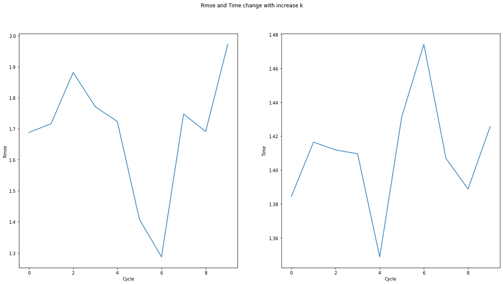

```python
fig, (ax1, ax2) = plt.subplots(1, 2,figsize=(20,10))
fig.suptitle('Rmse and Time change with increase k')
ax1.plot(range(numbercycles),rmsec)
ax2.plot(range(numbercycles),timec)
ax1.set(xlabel='Cycle', ylabel='Rmse')
ax2.set(xlabel='Cycle', ylabel='Time')
```

### Predictions

Below is the code to calculate predictions out of this model

```python
def getUserQueryVector(userQuery,mapiddict,size):
    result=np.full(size,np.nan)
    for i in userQuery:
        result[mapiddict[i]]=userQuery[i]
    return result

def getMapIdDictCols(df):
    mapiddict={}
    j=0
    for i in df.columns:
        mapiddict[i]=j
        j+=1
    return mapiddict,df.shape[1]

def getMapIdDictRows(df):
    mapiddict={}
    j=0
    for i in df.index:
        mapiddict[i]=j
        j+=1
    return mapiddict,df.shape[0]


def getUserPredictions(utilityMatrix,queryVector,size,k,globalave):

    if utilityMatrix.shape[0] == size+1:
        utilityMatrix[size]=queryVector
    else:
        utilityMatrix=np.append(utilityMatrix,queryVector.reshape(1,-1),axis=0)

    similarityMatrix=getSimilarityMatrix(pd.DataFrame(utilityMatrix))

    for i in range(len(queryVector)):
        if np.isnan(queryVector[i]):
            #if i==49:
            #    queryVector[i]=getRatingUBCF(utilityMatrix,similarityMatrix,size+1,i,k,globalave,debug=True)
            #else:
                r=getRatingUBCF(utilityMatrix,similarityMatrix,size+1,i,k,globalave,debug=False)
                #if r >6:
                #    print("WArningnnn",i,r)
                queryVector[i]=r
    return queryVector
```

Here I simulate some inputs from users to see what the response would be. To produce good results the model needs to get more data from the users to predict more accurately.

```python
topn=10
k=3
userQuery={2571:5,
           541:5,
          1214:4,
          1200:4,
          2999:1,
          3607:1,
          3233:1,
          3323:1
          }
globalave=np.nanmean(ratings_movies)
mapiddict,size=getMapIdDictCols(ratings_movies)
queryVector=getUserQueryVector(userQuery,mapiddict,size)
queryVector=getUserPredictions(utilityMatrix,queryVector,size,k,globalave)
queryindex=np.argsort(queryVector)
topmovies=queryindex[-topn:]
movies.iloc[topmovies]
```

| MovieID | Movie | Title | Year | Filename |
| --- | --- | --- | --- | --- |
| 350 | Client, The (1994) | The Client | 1994 | images/movies/350.jpg |
| 290 | Once Were Warriors (1994) | Once Were Warriors | 1994 | images/movies/290.jpg |
| 2626 | Edge of Seventeen (1998) | Edge of Seventeen | 1998 | images/movies/2626.jpg |
| 2854 | Don't Look in the Basement! (1973) | Dont Look in the Basement | 1973 | images/movies/2854.jpg |
| 517 | Rising Sun (1993) | Rising Sun | 1993 | images/movies/517.jpg |
| 1214 | Alien (1979) | Alien | 1979 | images/movies/1214.jpg |
| 1145 | Snowriders (1996) | Snowriders | 1996 | images/movies/1145.jpg |
| 1134 | Johnny 100 Pesos (1993) | Johnny Pesos | 1993 | images/movies/1134.jpg |
| 2720 | Inspector Gadget (1999) | Inspector Gadget | 1999 | images/movies/2720.jpg |
| 50 | Usual Suspects, The (1995) | The Usual Suspects | 1995 | images/movies/50.jpg |

```python
topn=10
k=3
userQuery={1:5,3:1
          }
globalave=np.nanmean(ratings_movies)
mapiddict,size=getMapIdDictCols(ratings_movies)
queryVector=getUserQueryVector(userQuery,mapiddict,size)
queryVector=getUserPredictions(utilityMatrix,queryVector,size,k,globalave)
queryindex=np.argsort(queryVector)
topmovies=queryindex[-topn:]
movies.iloc[topmovies]
```

| MovieID | Movie | Title | Year | Filename |
| --- | --- | --- | --- | --- |
| 350 | Client, The (1994) | The Client | 1994 | images/movies/350.jpg |
| 290 | Once Were Warriors (1994) | Once Were Warriors | 1994 | images/movies/290.jpg |
| 2626 | Edge of Seventeen (1998) | Edge of Seventeen | 1998 | images/movies/2626.jpg |
| 2854 | Don't Look in the Basement! (1973) | Dont Look in the Basement | 1973 | images/movies/2854.jpg |
| 517 | Rising Sun (1993) | Rising Sun | 1993 | images/movies/517.jpg |
| 1214 | Alien (1979) | Alien | 1979 | images/movies/1214.jpg |
| 1145 | Snowriders (1996) | Snowriders | 1996 | images/movies/1145.jpg |
| 1134 | Johnny 100 Pesos (1993) | Johnny Pesos | 1993 | images/movies/1134.jpg |
| 2720 | Inspector Gadget (1999) | Inspector Gadget | 1999 | images/movies/2720.jpg |
| 50 | Usual Suspects, The (1995) | The Usual Suspects | 1995 | images/movies/50.jpg |

## Item Based

### Model explanation.

The followign steps are going to prepare the data in a similar way for both recommendations systems. I am going to use a user werigthed average for the ratings before they are applied to any future process.

The process is doing a Pearson Correlation. This means before calculating the Similarity value the rating is adjusted according with the mean of the movies rating.

The formula is defined as

$$ r_{xi} = \frac{\sum_{j{\in}N(i,x)}s_{ij}\cdot(r_{xj}-b_{xj})}{\sum_{j{\in}N(i,x)}|s{ij}|} $$

Where

- $r_{xi}$ is the mean movie adjusted rating.
- $s_{ij}$ is the similarity distance using cosine similarity
- $r_{xj}$ rate of user X of movie j
- $b{xj}$ average rating of user x for movie j

The IBCF uses the relations ships between items to calculate similarity. In this case the objects are Movies and information is used to calculate a similary matrix with the above formula that allows to find similar items.

The evaluation will be performed using RMSE.

This is the model that is implemented in the interface.

### Data Preparation

This steps onle pivots the data to have a ful utility matrix. All operation are done using Numpy matrices operations so the data is also converted to a numpy array.

```python
ratings_movies = ratingsraw.pivot(index = 'UserID', columns ='MovieID', values = 'Rating')
ratings_movies=ratings_movies.T
utilityMatrix=ratings_movies.to_numpy()
```

```python
ratings_movies
```

| UserID MovieID | 1 | 2 | 3 | 4 | 5 | 6 | 7 | 8 | 9 | 10 | ... | 6031 | 6032 | 6033 | 6034 | 6035 | 6036 | 6037 | 6038 | 6039 | 6040 |
| --- | --- | --- | --- | --- | --- | --- | --- | --- | --- | --- | --- | --- | --- | --- | --- | --- | --- | --- | --- | --- | --- |
| 1 | 5.0 | NaN | NaN | NaN | NaN | 4.0 | NaN | 4.0 | 5.0 | 5.0 | ... | NaN | 4.0 | NaN | NaN | 4.0 | NaN | NaN | NaN | NaN | 3.0 |
| 2 | NaN | NaN | NaN | NaN | NaN | NaN | NaN | NaN | NaN | 5.0 | ... | NaN | NaN | NaN | NaN | NaN | NaN | NaN | NaN | NaN | NaN |
| 3 | NaN | NaN | NaN | NaN | NaN | NaN | NaN | NaN | NaN | NaN | ... | NaN | NaN | NaN | NaN | 1.0 | NaN | NaN | NaN | NaN | NaN |
| 4 | NaN | NaN | NaN | NaN | NaN | NaN | NaN | 3.0 | NaN | NaN | ... | NaN | NaN | NaN | NaN | 2.0 | 2.0 | NaN | NaN | NaN | NaN |
| 5 | NaN | NaN | NaN | NaN | NaN | NaN | NaN | NaN | NaN | NaN | ... | NaN | NaN | NaN | NaN | 1.0 | NaN | NaN | NaN | NaN | NaN |
| ... | ... | ... | ... | ... | ... | ... | ... | ... | ... | ... | ... | ... | ... | ... | ... | ... | ... | ... | ... | ... | ... |
| 3948 | NaN | NaN | NaN | NaN | NaN | NaN | NaN | NaN | 3.0 | 4.0 | ... | NaN | NaN | NaN | NaN | NaN | NaN | NaN | NaN | NaN | NaN |
| 3949 | NaN | NaN | NaN | NaN | NaN | NaN | NaN | NaN | NaN | NaN | ... | NaN | NaN | NaN | NaN | NaN | NaN | NaN | NaN | NaN | NaN |
| 3950 | NaN | NaN | NaN | NaN | NaN | NaN | NaN | NaN | NaN | NaN | ... | NaN | NaN | NaN | NaN | NaN | NaN | NaN | NaN | NaN | NaN |
| 3951 | NaN | NaN | NaN | NaN | NaN | NaN | NaN | NaN | NaN | NaN | ... | NaN | NaN | NaN | NaN | NaN | NaN | NaN | NaN | NaN | NaN |
| 3952 | NaN | NaN | NaN | NaN | NaN | NaN | NaN | NaN | NaN | NaN | ... | NaN | NaN | NaN | NaN | NaN | NaN | NaN | NaN | NaN | NaN |

3706 rows × 6040 columns

Saving the data for use in application

```python
utilitymatrixdf=ratings_movies.reset_index()

newcols=list()
for i in utilitymatrixdf.columns:
    #print (str(i))
    newcols.append(str(i))
utilitymatrixdf.columns=newcols
utilitymatrixdf.to_feather(os.path.join(basedata,'utilitymatrix.feather'))
utilitymatrixdf
```

|  | MovieID | 1 | 2 | 3 | 4 | 5 | 6 | 7 | 8 | 9 | ... | 6031 | 6032 | 6033 | 6034 | 6035 | 6036 | 6037 | 6038 | 6039 | 6040 |
| --- | --- | --- | --- | --- | --- | --- | --- | --- | --- | --- | --- | --- | --- | --- | --- | --- | --- | --- | --- | --- | --- |
| 0 | 1 | 5.0 | NaN | NaN | NaN | NaN | 4.0 | NaN | 4.0 | 5.0 | ... | NaN | 4.0 | NaN | NaN | 4.0 | NaN | NaN | NaN | NaN | 3.0 |
| 1 | 2 | NaN | NaN | NaN | NaN | NaN | NaN | NaN | NaN | NaN | ... | NaN | NaN | NaN | NaN | NaN | NaN | NaN | NaN | NaN | NaN |
| 2 | 3 | NaN | NaN | NaN | NaN | NaN | NaN | NaN | NaN | NaN | ... | NaN | NaN | NaN | NaN | 1.0 | NaN | NaN | NaN | NaN | NaN |
| 3 | 4 | NaN | NaN | NaN | NaN | NaN | NaN | NaN | 3.0 | NaN | ... | NaN | NaN | NaN | NaN | 2.0 | 2.0 | NaN | NaN | NaN | NaN |
| 4 | 5 | NaN | NaN | NaN | NaN | NaN | NaN | NaN | NaN | NaN | ... | NaN | NaN | NaN | NaN | 1.0 | NaN | NaN | NaN | NaN | NaN |
| ... | ... | ... | ... | ... | ... | ... | ... | ... | ... | ... | ... | ... | ... | ... | ... | ... | ... | ... | ... | ... | ... |
| 3701 | 3948 | NaN | NaN | NaN | NaN | NaN | NaN | NaN | NaN | 3.0 | ... | NaN | NaN | NaN | NaN | NaN | NaN | NaN | NaN | NaN | NaN |
| 3702 | 3949 | NaN | NaN | NaN | NaN | NaN | NaN | NaN | NaN | NaN | ... | NaN | NaN | NaN | NaN | NaN | NaN | NaN | NaN | NaN | NaN |
| 3703 | 3950 | NaN | NaN | NaN | NaN | NaN | NaN | NaN | NaN | NaN | ... | NaN | NaN | NaN | NaN | NaN | NaN | NaN | NaN | NaN | NaN |
| 3704 | 3951 | NaN | NaN | NaN | NaN | NaN | NaN | NaN | NaN | NaN | ... | NaN | NaN | NaN | NaN | NaN | NaN | NaN | NaN | NaN | NaN |
| 3705 | 3952 | NaN | NaN | NaN | NaN | NaN | NaN | NaN | NaN | NaN | ... | NaN | NaN | NaN | NaN | NaN | NaN | NaN | NaN | NaN | NaN |

3706 rows × 6041 columns

### Functions

The following functions help with the Ratings as well as the test train and validation of the model. The first function

```python
def getSimilarityMatrix(utilityDataFrame):
    # Calculates the mean for each row
    rowMean=utilityDataFrame.mean(1,True).to_numpy(np.float16)
    # Convers  the array to a matrix
    matrixRowMean=rowMean.reshape(-1,1)
    # Data Frame is converted into matrix sparce matrix
    utilityMatrix=utilityDataFrame.to_numpy(np.float16)
    utilityMatrixSparse = scipy.sparse.csc_matrix(utilityMatrix)
    # Each non Nan are substract the mean of the row.
    utilityMatrixCenter=utilityMatrixSparse-matrixRowMean
    # All Nan alements are converted to zero
    utilityMatrixCenterZero=np.nan_to_num(utilityMatrixCenter)
    # Cosine similarity matrix is calculated
    SimilarityMatrix = cosine_similarity(utilityMatrixCenterZero)
    return SimilarityMatrix
```

Randoming assings block of matrix for model verification

```python
def getTestTrainSplit(utilityMatrix,xsplit, ysplit):
    xl,yl=utilityMatrix.shape
    xts=xsplit
    yts=ysplit
    xs=np.random.randint(xl-xts)
    ys=np.random.randint(yl-yts)
    test=utilityMatrix[xs:xs+xts,ys:ys+yts].copy()
    train=utilityMatrix.copy()
    train[xs:xs+xts,ys:ys+yts]=np.nan
    return test,train,xs,xts,ys,yts
```

Calculates rating using IBCF

```python
def getRatingIBCF(colUtilityMatrix,rowSimilarityMatrix,top,debug=False):
    row=rowSimilarityMatrix

    col=colUtilityMatrix
    mask=~np.isnan(col)

    simrow=np.multiply(row,col)
    simcol=np.multiply(row,mask)

    validrow=simrow[mask]
    validcol=simcol[mask]

    sortedvalues=np.argsort(validcol)
    topn=sortedvalues[-top:]
    dt=np.sum(validrow[topn])
    db=np.sum(np.abs(validcol[topn]))
    result=(dt/db)
    return(result)
```

Calculates the missing ratings for entire matrix using IBCF

```python
def getFullRatingsIBCF(utilityMatrix,similarityMatrix,k):
    final=np.copy(utilityMatrix)
    v,h = utilityMatrix.shape
    for i in range(v):
        for j in range(h):
            if np.isnan(utilityMatrix[i,j]):
                    final[i,j]=getRatingIBCF(utilityMatrix[i],similarityMatrix[j],k,2)
        if (i%100==0):
            print("%s of total %s"%(i,v))
    return final
```

Calculates rmse for model IBCF

```python
def getRmseIBCF(actualData,train,xs,xts,ys,yts,k):
    sums=0
    n=0
    similarityMatrix=getSimilarityMatrix(pd.DataFrame(train))
    globalave=np.nanmean(actualData)
    for i in range(xs,xs+xts):
        for j in range(ys,ys+yts):
            if not np.isnan(actualData[i,j]):
                queryVector=train[:,j]
                vectorSimilarity=similarityMatrix[i]
                #print(len(vectorSimilarity),len(queryVector))
                result=getRatingIBCF(queryVector,vectorSimilarity,k,debug=False)
                sums=sums+(result-actualData[i,j])**2
                n=n+1
    rmse=np.sqrt(sums/n)
    return rmse
```

### Evaluation

The first step in the evalution process is to find the correct value for the k neighbors. This steps does a loop across to find a optimal k value.

```python
test,train,xs,xts,ys,yts=getTestTrainSplit(utilityMatrix,200,100)

mink=2
topk=30
i=0
step=1
rmsek=np.zeros(len(range(mink,topk,step)))
timek=np.zeros(len(range(mink,topk,step)))
for k in range(mink,topk,step):
    start_time = time.time()
    rmsek[i]=getRmseIBCF(utilityMatrix,train,xs,xts,ys,yts,k)
    timek[i]=(time.time() - start_time)
    i+=1
```

```
[Text(0.5, 0, 'K Value'), Text(0, 0.5, 'Time')]
```

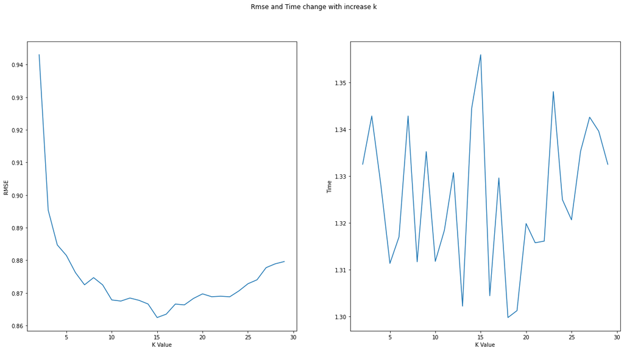

```python
fig, (ax1, ax2) = plt.subplots(1, 2,figsize=(20,10))
fig.suptitle('Rmse and Time change with increase k')
ax1.plot(range(mink,topk,step),rmsek)
ax2.plot(range(mink,topk,step),timek)
ax1.set(xlabel='K Value', ylabel='RMSE')
ax2.set(xlabel='K Value', ylabel='Time')
```

### Iterations

```python
k=15
numbercycles=10
rmsec=np.zeros(numbercycles)
timec=np.zeros(numbercycles)
for i in range(numbercycles):
    test,train,xs,xts,ys,yts=getTestTrainSplit(utilityMatrix,200,100)
    start_time = time.time()
    rmsec[i]=getRmseIBCF(utilityMatrix,train,xs,xts,ys,yts,k)
    timec[i]=(time.time() - start_time)
```

```
[Text(0.5, 0, 'Cycle'), Text(0, 0.5, 'Time')]
```

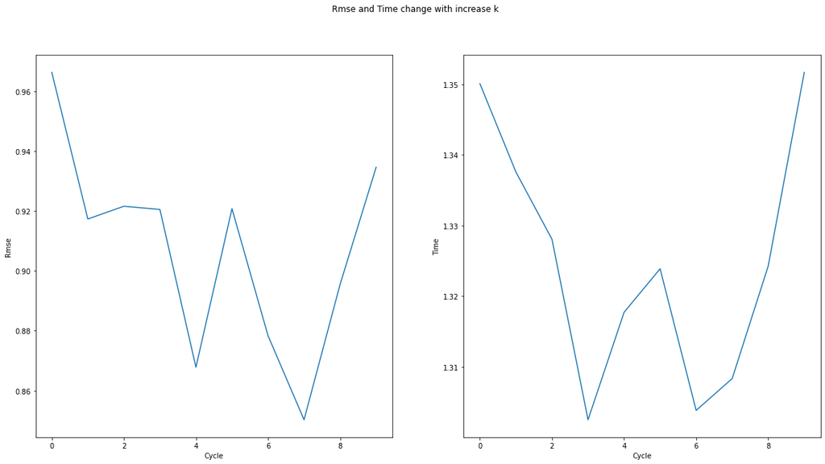

```python
fig, (ax1, ax2) = plt.subplots(1, 2,figsize=(20,10))
fig.suptitle('Rmse and Time change with increase k')
ax1.plot(range(numbercycles),rmsec)
ax2.plot(range(numbercycles),timec)
ax1.set(xlabel='Cycle', ylabel='Rmse')
ax2.set(xlabel='Cycle', ylabel='Time')
```

### Predictions

The following are just functions required by the process.

```python
ratings_movies = ratingsraw
valid_movies=pd.DataFrame(ratings_movies['MovieID'].unique())
valid_movies.columns=['MovieID']
valid_movies.to_feather(os.path.join(basedata,'validmovies.feather'))
validMovies=valid_movies['MovieID'].to_numpy()
```

```python
def getMapIdDictCols():
    mapiddict={}
    j=0
    for i in validMovies:
        mapiddict[i]=j
        j+=1
    return mapiddict,len(validMovies)

def getUserQueryVector(userQuery):
    mapiddict,size=getMapIdDictCols()
    result=np.full(size,np.nan)
    for i in userQuery:
        result[mapiddict[i]]=userQuery[i]
    return result


def getUserPredictions(queryVector,k):
    for i in range(len(queryVector)):
        if np.isnan(queryVector[i]):
                vectorSimilarity=similarityMatrix[i]
                #print(vectorSimilarity)
                r=getRatingIBCF(queryVector,vectorSimilarity,k,debug=False)
                #print(r)
                queryVector[i]=r
    return queryVector
```

I simulate a input from the user and get a list of results

```python
topn=10
k=15
userQuery={19:5
          }
queryVector=getUserQueryVector(userQuery)
queryVector=getUserPredictions(queryVector,k)
print (queryVector)
queryindex=np.argsort(queryVector)
topmovies=queryindex[-topn:]
movies.iloc[topmovies]
```

```
[5.         5.00000026 4.99999991 ... 4.20801561 4.19934843 4.1826452 ]
```

| MovieID | Movie | Title | Year | Filename |
| --- | --- | --- | --- | --- |
| 2100 | Splash (1984) | Splash | 1984 | images/movies/2100.jpg |
| 3605 | King Creole (1958) | King Creole | 1958 | images/movies/3605.jpg |
| 1927 | All Quiet on the Western Front (1930) | All Quiet on the Western Front | 1930 | images/movies/1927.jpg |
| 1795 | Callej�n de los milagros, El (1995) | Callejn de los milagros El | 1995 | images/movies/1795.jpg |
| 1787 | Paralyzing Fear: The Story of Polio in America... | Paralyzing Fear The Story of Polio in America A | 1998 | images/movies/1787.jpg |
| 1721 | Titanic (1997) | Titanic | 1997 | images/movies/1721.jpg |
| 1720 | Time Tracers (1995) | Time Tracers | 1995 | images/movies/1720.jpg |
| 1713 | Mouse Hunt (1997) | Mouse Hunt | 1997 | images/movies/1713.jpg |
| 2103 | Tall Tale (1994) | Tall Tale | 1994 | images/movies/2103.jpg |
| 1241 | Braindead (1992) | Braindead | 1992 | images/movies/1241.jpg |

```python
topn=10
k=15
userQuery={1:5,3:1
          }
queryVector=getUserQueryVector(userQuery)
queryVector=getUserPredictions(queryVector,k)
print (queryVector)
queryindex=np.argsort(queryVector)
topmovies=queryindex[-topn:]
movies.iloc[topmovies]
```

```
[2.56720141 1.88263778 1.8227818  ... 1.93257168 2.12355403 1.99828222]
```

| MovieID | Movie | Title | Year | Filename |
| --- | --- | --- | --- | --- |
| 1053 | Normal Life (1996) | Normal Life | 1996 | images/movies/1053.jpg |
| 3514 | Joe Gould's Secret (2000) | Joe Goulds Secret | 2000 | images/movies/3514.jpg |
| 1014 | Pollyanna (1960) | Pollyanna | 1960 | images/movies/1014.jpg |
| 938 | Gigi (1958) | Gigi | 1958 | images/movies/938.jpg |
| 928 | Rebecca (1940) | Rebecca | 1940 | images/movies/928.jpg |
| 845 | Day the Sun Turned Cold, The (1994) | The Day the Sun Turned Cold | 1994 | images/movies/845.jpg |
| 836 | Chain Reaction (1996) | Chain Reaction | 1996 | images/movies/836.jpg |
| 831 | Stonewall (1995) | Stonewall | 1995 | images/movies/831.jpg |
| 823 | Collectionneuse, La (1967) | Collectionneuse La | 1967 | images/movies/823.jpg |
| 3478 | Bamba, La (1987) | Bamba La | 1987 | images/movies/3478.jpg |

Saving similary matrix for use in the inteface

```python
similaritydf=pd.DataFrame(similarityMatrix)

newcols=list()
for i in similaritydf.columns:
    #print (str(i))
    newcols.append(str(i))
similaritydf.columns=newcols
similaritydf.to_feather(os.path.join(basedata,'similarity.feather'))
similaritydf
```

|  | 0 | 1 | 2 | 3 | 4 | 5 | 6 | 7 | 8 | 9 | ... | 3696 | 3697 | 3698 | 3699 | 3700 | 3701 | 3702 | 3703 | 3704 | 3705 |
| --- | --- | --- | --- | --- | --- | --- | --- | --- | --- | --- | --- | --- | --- | --- | --- | --- | --- | --- | --- | --- | --- |
| 0 | 1.000027 | 0.075204 | 0.045765 | 0.072367 | 0.042958 | 0.019059 | 0.043898 | 0.022827 | -0.003892 | 0.055660 | ... | -0.012770 | 0.000689 | 0.016980 | 0.011345 | 0.032417 | 0.044015 | 0.032336 | 0.013256 | 0.011594 | 0.028426 |
| 1 | 0.075204 | 1.000004 | 0.035495 | 0.011160 | 0.087783 | 0.026300 | 0.062679 | 0.056883 | 0.072497 | 0.105427 | ... | -0.012531 | -0.008622 | 0.015644 | 0.010802 | -0.005963 | 0.051541 | 0.006003 | -0.012174 | -0.006405 | 0.005528 |
| 2 | 0.045765 | 0.035495 | 1.000003 | 0.055369 | 0.131079 | 0.045298 | 0.070046 | 0.033131 | 0.026096 | 0.072439 | ... | 0.002758 | 0.010575 | -0.015793 | 0.014985 | 0.016107 | 0.058374 | 0.000546 | 0.026164 | 0.017784 | 0.014763 |
| 3 | 0.072367 | 0.011160 | 0.055369 | 1.000002 | 0.125875 | 0.002572 | 0.016767 | 0.007400 | -0.048337 | -0.001591 | ... | 0.033410 | 0.015428 | 0.009578 | 0.014658 | -0.005590 | 0.032883 | -0.052818 | 0.010576 | -0.011551 | 0.011968 |
| 4 | 0.042958 | 0.087783 | 0.131079 | 0.125875 | 1.000003 | 0.017869 | 0.082446 | 0.050665 | 0.084512 | 0.052423 | ... | -0.017938 | 0.027484 | 0.000243 | 0.014622 | 0.028855 | 0.067766 | -0.016561 | 0.012366 | 0.000141 | -0.003141 |
| ... | ... | ... | ... | ... | ... | ... | ... | ... | ... | ... | ... | ... | ... | ... | ... | ... | ... | ... | ... | ... | ... |
| 3701 | 0.044015 | 0.051541 | 0.058374 | 0.032883 | 0.067766 | 0.022105 | 0.011984 | 0.028143 | 0.002227 | 0.044322 | ... | 0.011407 | 0.015009 | 0.039775 | 0.050493 | 0.001404 | 0.999990 | 0.027763 | 0.005301 | -0.021231 | 0.042989 |
| 3702 | 0.032336 | 0.006003 | 0.000546 | -0.052818 | -0.016561 | 0.011052 | 0.001309 | -0.043058 | -0.000622 | 0.006563 | ... | 0.050060 | 0.061976 | -0.027754 | 0.020550 | 0.028935 | 0.027763 | 1.000002 | 0.040670 | 0.136150 | 0.049241 |
| 3703 | 0.013256 | -0.012174 | 0.026164 | 0.010576 | 0.012366 | -0.020324 | 0.015468 | 0.072959 | -0.006894 | 0.005872 | ... | -0.007575 | 0.057944 | -0.068627 | -0.097052 | 0.044449 | 0.005301 | 0.040670 | 1.000000 | 0.039822 | 0.066706 |
| 3704 | 0.011594 | -0.006405 | 0.017784 | -0.011551 | 0.000141 | -0.005432 | 0.029532 | -0.000121 | 0.000000 | -0.006367 | ... | 0.035226 | 0.112556 | -0.039564 | 0.071283 | 0.021308 | -0.021231 | 0.136150 | 0.039822 | 1.000000 | 0.110404 |
| 3705 | 0.028426 | 0.005528 | 0.014763 | 0.011968 | -0.003141 | 0.016373 | -0.008393 | -0.008263 | -0.011469 | 0.045466 | ... | 0.062111 | 0.079501 | -0.023050 | 0.006272 | 0.019588 | 0.042989 | 0.049241 | 0.066706 | 0.110404 | 1.000000 |

3706 rows × 3706 columns